# Lab 4c: Deep Learning - iNaturalist

Mia Forsline

2021-03-02

# Deep Learning with R/Python using iNaturalist

- apply techniques from Ch. 5 to a small subset of [iNaturalist species imagery](https://github.com/visipedia/inat_comp/tree/master/2021)
  - we will be using the Train Mini subset of data

# Data Pre-Processing

## Create image directories

- Note there are 10,000 possible species

```r
# path to folder containing species directories of images
dir_train_mini <- "/courses/EDS232/inaturalist-2021/train_mini"

# get list of directories, one per species (n = 10,000 species)
dirs_spp <- list.dirs(dir_train_mini, recursive = F)
n_spp <- length(dirs_spp)
n_spp
```

```
## [1] 10000
```

## Set seed and generate 10 random species for multi-class classification

```r
# set seed (for reproducible results)
# just before sampling (otherwise get different results)
# based on your username (unique amongst class)
Sys.info()[["user"]] %>%
  digest::digest2int() %>%
  set.seed()
i10 <- sample(1:n_spp, 10)

# show the 10 indices sampled of the 10,000 possible
i10
```

```
##  [1] 9102 2916 3087 4497 6555  348 3702 4520 4264 4055
```

```r
sp10 <- basename(dirs_spp)[i10]
```

View the 10 random species names

```r
# show the 10 species directory names
basename(dirs_spp)[i10]
```

```
##  [1] "09101_Plantae_Tracheophyta_Magnoliopsida_Oxalidales_Oxalidaceae_Oxalis_obtusa"
##  [2] "02915_Animalia_Chordata_Actinopterygii_Syngnathiformes_Aulostomidae_Aulostomus_chinensis"
##  [3] "03086_Animalia_Chordata_Amphibia_Caudata_Plethodontidae_Eurycea_wilderae"
##  [4] "04496_Animalia_Chordata_Aves_Psittaciformes_Cacatuidae_Cacatua_sanguinea"
##  [5] "06554_Plantae_Tracheophyta_Magnoliopsida_Apiales_Araliaceae_Fatsia_japonica"
##  [6] "00347_Animalia_Arthropoda_Insecta_Coleoptera_Elateridae_Alaus_lusciosus"
##  [7] "03701_Animalia_Chordata_Aves_Passeriformes_Bombycillidae_Bombycilla_cedrorum"
##  [8] "04519_Animalia_Chordata_Aves_Psittaciformes_Psittacidae_Psittacara_leucophthalmus"
##  [9] "04263_Animalia_Chordata_Aves_Passeriformes_Troglodytidae_Troglodytes_hiemalis"
## [10] "04054_Animalia_Chordata_Aves_Passeriformes_Parulidae_Leiothlypis_luciae"
```

## Generate 2 species for binary classification

```r
# show the first 2 species directory names
i2 <- i10[1:2]
sp2 <- basename(dirs_spp)[i2]

obtusa <- basename(dirs_spp)[i2][1]
chinensis <- basename(dirs_spp)[i2][2]
```

## Create dataframe of species and file paths

```r
# path to output table of paths, which could be read by R, eg readr::read_csv(), or Python, eg pandas.read_csv()
inat_spp_images_csv <- "~/inat_spp_images.csv"

d <- tibble(
  # get 10 species names
  species = basename(dirs_spp)[i10],
  # assign TRUE/FALSE for: 10 species (multi-class) and 2 species (binary)
  spp10 = TRUE,
  spp2  = c(T,T,rep(F,8)))
DT::datatable(d)
```

|  | species | spp10 | spp2 |
| --- | --- | --- | --- |
| 1 | 09101_Plantae_Tracheophyta_Magnoliopsida_Oxalidales_Oxalidaceae_Oxalis_obtusa | True | True |
| 2 | 02915_Animalia_Chordata_Actinopterygii_Syngnathiformes_Aulostomidae_Aulostomus_chinensis | True | True |
| 3 | 03086_Animalia_Chordata_Amphibia_Caudata_Plethodontidae_Eurycea_wilderae | True | False |
| 4 | 04496_Animalia_Chordata_Aves_Psittaciformes_Cacatuidae_Cacatua_sanguinea | True | False |
| 5 | 06554_Plantae_Tracheophyta_Magnoliopsida_Apiales_Araliaceae_Fatsia_japonica | True | False |
| 6 | 00347_Animalia_Arthropoda_Insecta_Coleoptera_Elateridae_Alaus_lusciosus | True | False |
| 7 | 03701_Animalia_Chordata_Aves_Passeriformes_Bombycillidae_Bombycilla_cedrorum | True | False |
| 8 | 04519_Animalia_Chordata_Aves_Psittaciformes_Psittacidae_Psittacara_leucophthalmus | True | False |
| 9 | 04263_Animalia_Chordata_Aves_Passeriformes_Troglodytidae_Troglodytes_hiemalis | True | False |
| 10 | 04054_Animalia_Chordata_Aves_Passeriformes_Parulidae_Leiothlypis_luciae | True | False |

```r
d <- d %>%
  mutate(
    # construct full path to species directory
    dir_species = file.path(dir_train_mini, species),
    tbl_images  = purrr::map(dir_species, function(dir){
      # create a tibble per species
      tibble(
        # list files in the species directory (n=50)
        image = list.files(dir),
        # assign subset per species
        subset = c(rep("train", 30), rep("validation", 10), rep("test", 10))) })) %>%
  # go from a tibble with 10 species rows containing a nested tbl_images to unnested, ie 10 species * 50 images = 500 rows
  tidyr::unnest(tbl_images)

# write tibble to CSV file for subsequent reading
## save CSV in data folder
readr::write_csv(d, "data/inat_spp_images.csv", inat_spp_images_csv)

# show counts of image files per species and subset
d %>%
  mutate(
    # truncate species to show one line per species
    species_trunc = stringr::str_trunc(species, 40)) %>%
  select(species_trunc, subset) %>%
  table()
```

```
##                                           subset
## species_trunc                              test train validation
##   00347_Animalia_Arthropoda_Insecta_Col...   10    30         10
##   02915_Animalia_Chordata_Actinopterygi...   10    30         10
##   03086_Animalia_Chordata_Amphibia_Caud...   10    30         10
##   03701_Animalia_Chordata_Aves_Passerif...   10    30         10
##   04054_Animalia_Chordata_Aves_Passerif...   10    30         10
##   04263_Animalia_Chordata_Aves_Passerif...   10    30         10
##   04496_Animalia_Chordata_Aves_Psittaci...   10    30         10
##   04519_Animalia_Chordata_Aves_Psittaci...   10    30         10
##   06554_Plantae_Tracheophyta_Magnoliops...   10    30         10
##   09101_Plantae_Tracheophyta_Magnoliops...   10    30         10
```

## Create training, validation, and test directories

```r
original_dataset_dir <- "/courses/EDS232/inaturalist-2021/train_mini"
base_dir             <- "~/eds232/eds232-dl/data"
```

# 1. **2 Species (binary classification) - neural net**.

- Based on the [3.4 Movies example (binary classification)](https://bbest.github.io/eds232-ml/lab4b_3.4.movies.html)
- I will be using 2 randomly assigned species:
  - 09101_Plantae_Tracheophyta_Magnoliopsida_Oxalidales_Oxalidaceae_Oxalis_obtusa
  - 02915_Animalia_Chordata_Actinopterygii_Syngnathiformes_Aulostomidae_Aulostomus_chinensis

## Create general directories for binary classification

```r
# base directories
train_dir_2 <- file.path(base_dir, "train_2")
validation_dir_2 <- file.path(base_dir, "validation_2")
test_dir_2 <- file.path(base_dir, "test_2")

# create base train, validate, test directories
dir.create(train_dir_2)
dir.create(validation_dir_2)
dir.create(test_dir_2)
```

## Create directories for binary classification of 2 species

```r
# for loop to create species specific train, validate, and test directories
# named directories using the unique 5 digit characters at the start of the file
for (i in 1:length(sp2)){
  dir.create(file.path(train_dir_2, str_sub(sp2[[i]], start = 1, end = 5)))
  dir.create(file.path(validation_dir_2, str_sub(sp2[[i]], start = 1, end = 5)))
  dir.create(file.path(test_dir_2, str_sub(sp2[[i]], start = 1, end = 5)))
}
```

## Add images into the directories for binary classification of 2 species

```r
# create test, validation, and training groups of images
for(i in 1:length(sp2)){
  # create 5 groups of 10 random samples
  species_samples_2 <- replicate(5, sample(list.files(paste0(original_dataset_dir, "/", sp2[[i]]),
                                                    full.names = TRUE), replace = FALSE, 10))
  ## train n = 30 ##
  train <- rbind(species_samples_2[,1], species_samples_2[,2], species_samples_2[,3])
  file.copy(from = train,
            to = paste0(train_dir_2, "/", str_sub(sp2[[i]], start = 1, end = 5)), overwrite = TRUE)
  ## validation n = 10 ##
  validate <- species_samples_2[,4]
  file.copy(from = validate,
            to = paste0(validation_dir_2, "/", str_sub(sp2[[i]], start = 1, end = 5)), overwrite = TRUE)
  ## train n = 10 ##
  test <- species_samples_2[,5]
  file.copy(from = test,
            to = paste0(test_dir_2, "/", str_sub(sp2[[i]], start = 1, end = 5)), overwrite = TRUE)
}
```

Check how many images are in each directory

```r
# sanity check that the training dataset has 30, the validation set has 10, and the test dataset has 10 images per species
for (i in 1:length(sp2)){
  cat("total training images", length(list.files(file.path(train_dir_2, str_sub(sp2[[i]], start = 1, end = 5)))), "\n")
  cat("total validation images", length(list.files(file.path(validation_dir_2, str_sub(sp2[[i]], start = 1, end = 5)))), "\n")
  cat("total test images", length(list.files(file.path(test_dir_2, str_sub(sp2[[i]], start = 1, end = 5)))), "\n")
}
```

```
## total training images 36
## total validation images 16
## total test images 17
## total training images 38
## total validation images 18
## total test images 18
```

## Rescale images using `image_data_generator()`

- Turns image files on disk into batches of pre-processed tensors
- Image pixel values range 0 - 255, but we want values between [0,1]
- Neural networks prefer to deal with small input values

```r
# All images will be rescaled by 1/255
train_datagen <- image_data_generator(rescale = 1/255)
validation_datagen <- image_data_generator(rescale = 1/255)
test_datagen <- image_data_generator(rescale = 1/255)

train_generator <- flow_images_from_directory(
  # This is the target directory
  train_dir_2,
  # This is the data generator
  train_datagen,
  # All images will be resized to 150x150
  target_size = c(150, 150),
  batch_size = 5,
  # Since we use binary_crossentropy loss, we need binary labels
  class_mode = "binary")

validation_generator <- flow_images_from_directory(
  validation_dir_2,
  validation_datagen,
  target_size = c(150, 150),
  batch_size = 5,
  class_mode = "binary")

test_generator <- flow_images_from_directory(
  test_dir_2,
  test_datagen,
  target_size = c(150, 150),
  batch_size = 5,
  class_mode = "binary")
```

A generator yields batches of 150 x 150 RGB images and binary labels

```r
batch <- generator_next(train_generator)
str(batch)
```

```
## List of 2
##  $ : num [1:5, 1:150, 1:150, 1:3] 0.22745 0.18039 0.00392 0.76471 0.33333 ...
##  $ : num [1:5(1d)] 0 0 0 0 0
```

## Build the network

- input data is vectors
- labels are scalars (1s and 0s)
- **relu (rectified linear unit)**: function to zero-out negative values
- **sigmoid**: "squashes arbitrary values into the [0,1] interval so the output is a probability
- decide how many layers to use
- decide how many “hidden units” per layer
  - how much freedom are you allowing the network to have when learning
  - more hidden units = higher-dimensional representation space = network can learn more complex representations but will be more computationally expensive and may learn unwanted patterns (overfitting)

```r
model <- keras_model_sequential() %>%
  layer_dense(units = 16, activation = "relu", input_shape = c(150, 150, 3)) %>%
  layer_flatten() %>%
  layer_dense(units = 16, activation = "relu") %>%
  layer_dense(units =  1, activation = "sigmoid")
```

## Pick a loss function and an optimizer

- binary classification = the output of the network is a probability
- thus we want to use `binary_crossentropy` loss
- we will use the `rmsprop` optimizer
- we also want to measure accuracy

```r
model %>% compile(
  optimizer = "rmsprop",
  loss      = "binary_crossentropy",
  metrics   = c("accuracy"))
```

```r
history <- model %>% fit(
    train_generator,
    steps_per_epoch = 5,
    epochs = 30,
    validation_data = validation_generator,
    validation_steps = 5)
```

## Visualize the training and validation metrics by epoch with a history plot

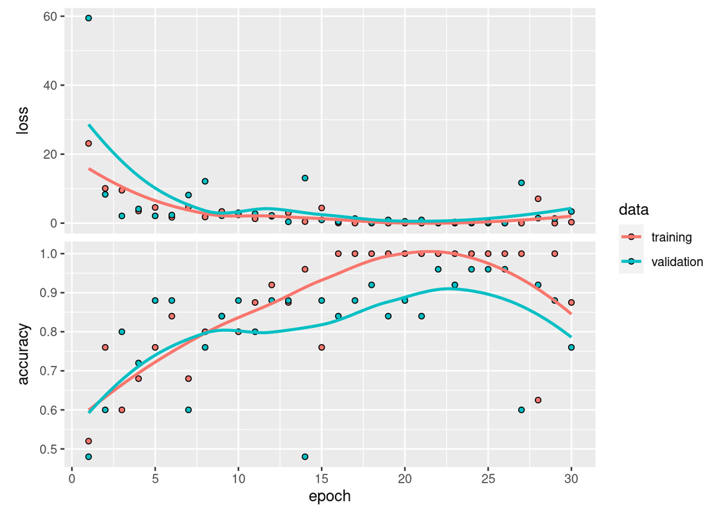

```r
plot(history)
```

## Evaluate the model on test data

```r
test_generator <- flow_images_from_directory(
  test_dir_2,
  test_datagen,
  target_size = c(150, 150),
  batch_size = 20,
  class_mode = "binary"
)
results <- model %>% evaluate_generator(test_generator, steps = 50)

loss <- round(results[[1]], digits = 2)
accuracy <- round(results [[2]], digits = 2)
```

The standard neural network for binary classification demonstrated a loss of approximately 1.71 and accuracy of approximately 0.86.

# 2. **Species (binary classification) - convolutional neural net**.

## Make the new model

- the covnet is a stack of alternated `layer_conv_2d()` with `relu` activation and `layer_max_pooling_2d()` stages
- use `layer_dense()` size of 1 + `sigmoid` activation because we’re using binary classification

```r
model <- keras_model_sequential() %>%
  layer_conv_2d(
    filters = 32, kernel_size = c(3, 3), activation = "relu",
    input_shape = c(150, 150, 3)) %>%
  layer_max_pooling_2d(pool_size = c(2, 2)) %>%
  layer_conv_2d(filters = 64, kernel_size = c(3, 3), activation = "relu") %>%
  layer_max_pooling_2d(pool_size = c(2, 2)) %>%
  layer_conv_2d(filters = 128, kernel_size = c(3, 3), activation = "relu") %>%
  layer_max_pooling_2d(pool_size = c(2, 2)) %>%
  layer_conv_2d(filters = 128, kernel_size = c(3, 3), activation = "relu") %>%
  layer_max_pooling_2d(pool_size = c(2, 2)) %>%
  layer_flatten() %>%
  layer_dropout(rate = 0.5) %>%
  layer_dense(units = 512, activation = "relu") %>%
  layer_dense(units = 1, activation = "sigmoid")
```

## Compile the model using `RMSprop` optimizer

- use `binary_crossentropy` loss function

```r
model %>% compile(
  loss = "binary_crossentropy",
  optimizer = optimizer_rmsprop(learning_rate = 1e-4),
  metrics = c("acc"))
```

## Fit the model

```r
history_2 <- model %>% fit(
    train_generator,
    steps_per_epoch = 5,
    epochs = 30,
    validation_data = validation_generator,
    validation_steps = 5)
history_2
```

```
##
## Final epoch (plot to see history):
##     loss: 0.3207
##      acc: 0.92
## val_loss: 0.2655
##  val_acc: 0.92
```

## History plot

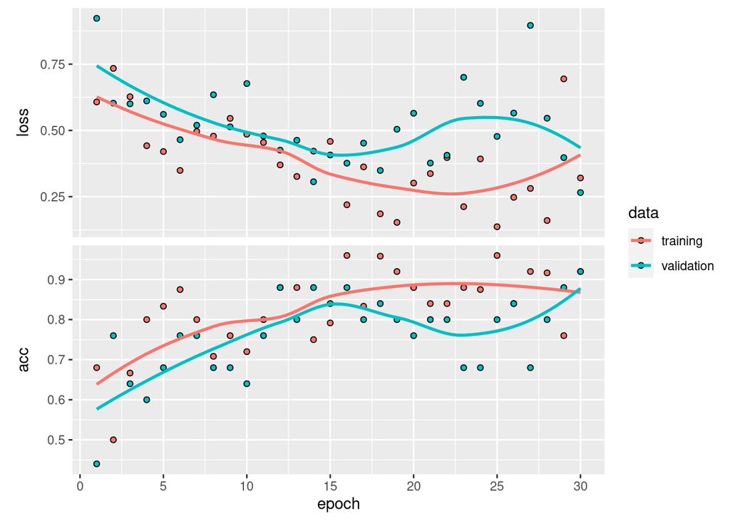

```r
plot(history_2)
```

## Evaluate the model using test data

```r
test_generator_2 <- flow_images_from_directory(
  test_dir_2,
  test_datagen,
  target_size = c(150, 150),
  batch_size = 5,
  class_mode = "binary"
)
results <- model %>% evaluate(test_generator_2, steps = 50)
loss2 <- round(results [[1]], digits = 2)
accuracy2 <- round(results[[2]], digits = 2)
```

The convolutional neural network for binary classification demonstrated a loss of approximately 0.28 and accuracy of approximately 0.89.

## Compare neural net vs convolutional neural net for binary classification

For binary classification, the convolutional neural net outperformed the standard neural net with a higher accuracy and lower loss function.

# 3. **10 Species (multi-class classification) - neural net**

## Create directories for multi-class classifications (10 species)

```r
original_dataset_dir <- "/courses/EDS232/inaturalist-2021/train_mini"
base_dir             <- "~/eds232/eds232-dl/data"

# base directories
train_dir_10 <- file.path(base_dir, "train_10")
validation_dir_10 <- file.path(base_dir, "validation_10")
test_dir_10 <- file.path(base_dir, "test_10")

# create base train, validate, test directories
dir.create(train_dir_10)
dir.create(validation_dir_10)
dir.create(test_dir_10)

for (i in 1:length(sp10)){
  dir.create(file.path(train_dir_10, str_sub(sp10[[i]], start = 1, end = 5)))
  dir.create(file.path(validation_dir_10, str_sub(sp10[[i]], start = 1, end = 5)))
  dir.create(file.path(test_dir_10, str_sub(sp10[[i]], start = 1, end = 5)))
}
```

## Add images into directories for 10 species

```r
for(i in 1:length(sp10)){
  # create 5 groups of 10 random samples
  species_samples_10 <- replicate(5,
                                  sample(list.files(paste0(original_dataset_dir, "/", sp10[[i]]),
                                                    full.names = TRUE), replace = FALSE, 10))
  ## train n = 30 ##
  train <- rbind(species_samples_10[,1], species_samples_10[,2], species_samples_10[,3])
  file.copy(from = train,
            to = paste0(train_dir_10, "/", str_sub(sp10[[i]], start = 1, end = 5)),
            overwrite = TRUE)
  ## validation n = 10 ##
  validate <- species_samples_10[,4]
  file.copy(from = validate,
            to = paste0(validation_dir_10, "/", str_sub(sp10[[i]], start = 1, end = 5)),
            overwrite = TRUE)
  ## train n = 10 ##
  test <- species_samples_10[,5]
  file.copy(from = test,
            to = paste0(test_dir_10, "/", str_sub(sp10[[i]], start = 1, end = 5)),
            overwrite = TRUE)
}
```

## Check number of images per folder

```r
# sanity check that the training dataset has 30, the validation set has 10, and the test dataset has 10 images per species
for (i in 1:length(sp10)){
  cat("total training images", length(list.files(file.path(train_dir_10, str_sub(sp10[[i]], start = 1, end = 5)))), "\n")
  cat("total validation images", length(list.files(file.path(validation_dir_10, str_sub(sp10[[i]], start = 1, end = 5)))), "\n")
  cat("total test images", length(list.files(file.path(test_dir_10, str_sub(sp10[[i]], start = 1, end = 5)))), "\n")
}
```

```
## total training images 50
## total validation images 37
## total test images 34
## total training images 48
## total validation images 37
## total test images 35
## total training images 47
## total validation images 33
## total test images 32
## total training images 49
## total validation images 31
## total test images 32
## total training images 49
## total validation images 31
## total test images 32
## total training images 50
## total validation images 30
## total test images 32
## total training images 50
## total validation images 30
## total test images 33
## total training images 48
## total validation images 35
## total test images 33
## total training images 48
## total validation images 35
## total test images 33
## total training images 50
## total validation images 34
## total test images 30
```

## Rescale and pre-process images from 10 species

```r
# pre process the images from the 10 species using categorical class
# All images will be rescaled by 1/255
test_datagen_10 <- image_data_generator(rescale = 1/255)
train_datagen_10 <- image_data_generator(rescale = 1/255)
validation_datagen_10 <- image_data_generator(rescale = 1/255)

train_generator_10 <- flow_images_from_directory(
  # This is the target directory
  train_dir_10,
  # This is the data generator
  train_datagen_10,
  # All images will be resized to 150x150
  target_size = c(150, 150),
  batch_size = 5,
  # change label to categorical
  class_mode = "categorical")

validation_generator_10 <- flow_images_from_directory(
  validation_dir_10,
  validation_datagen_10,
  target_size = c(150, 150),
  batch_size = 5,
  class_mode = "categorical")

test_generator_10 <- flow_images_from_directory(
  test_dir_10,
  test_datagen_10,
  target_size = c(150, 150),
  batch_size = 5,
  class_mode = "categorical")


batch <- generator_next(train_generator_10)
str(batch)
```

```
## List of 2
##  $ : num [1:5, 1:150, 1:150, 1:3] 0.3804 0.4588 0.3647 0.0196 0.7529 ...
##  $ : num [1:5, 1:10] 0 0 0 0 0 0 0 0 0 0 ...
```

## Build the network

- compared to binary classification, the dimensionality of multi-class classification output is much larger
- for binary classification, we used 16-dimensional space in our stack of dense layers
  - however, if one layer drops information, that lost information cannot be recovered by later layers
  - each layer can become an *information bottleneck*
- to overcome this problem, we will use 64 units instead of 16
- also note that we end the network with a dense layer of size 10 (not 64) in order to output a 10-dimensional vector to encode a different output class (remember, we have 10 different species)
- the last layer uses `softmax` activation so the network will output a probability distribution over 10 different output classes

```r
model <- keras_model_sequential() %>%
  layer_dense(units = 64, activation = "relu", input_shape = c(150, 150, 3)) %>%
  layer_flatten() %>%
  layer_dense(units = 64, activation = "relu") %>%
  layer_dense(units =  10, activation = "softmax")
```

## Select a loss function

- we will continue to use the `rmsprop` optimizer
- but now we will use the `categorical_crossentropy` loss function to measure the distance between 2 probability distributions
  - between the probability distribution output by our network and the true distribution of the labels
  - we want to minimize this distance to train our network to output something as close as possible to the true labels

```r
model %>% compile(
  optimizer = "rmsprop",
  loss = "categorical_crossentropy",
  metrics = c("accuracy")
)
```

## Fit the model

```r
#sometimes this line runs into an error - but restarting the R session + clearing the global environment usually clears up the error
history_3 <- model %>% fit(
  train_generator_10,
  steps_per_epoch = 5,
  epochs = 30,
  validation_data = validation_generator_10,
  validation_steps = 5)
```

## History plot

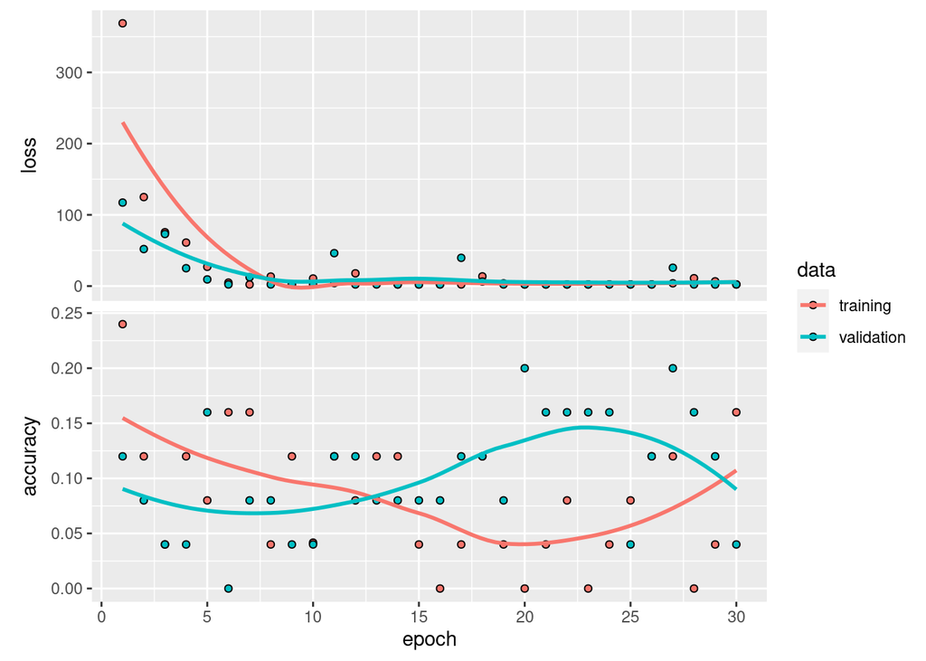

```r
plot(history_3)
```

## Evaluate the model

```r
test_generator_3 <- flow_images_from_directory(
  test_dir_10,
  test_datagen_10,
  target_size = c(150, 150),
  batch_size = 20,
  class_mode = "categorical"
)
results3 <- model %>% evaluate(test_generator_3, steps = 50)
loss3 <- round(results3[[1]], digits = 2)
accuracy3 <- round(results3[[2]], digits = 2)
```

The multi-class classification standard neural net demonstrated a loss of approximately 2.3 and an accuracy rate of approximately 0.12.

# 4. **10 Species (multi-class classification) - convolutional neural net**.

## Build the network

```r
# make the new model
model <- keras_model_sequential() %>%
  layer_conv_2d(
    filters = 32, kernel_size = c(3, 3), activation = "relu",
    input_shape = c(150, 150, 3)) %>%
  layer_max_pooling_2d(pool_size = c(2, 2)) %>%
  layer_conv_2d(filters = 64, kernel_size = c(3, 3), activation = "relu") %>%
  layer_max_pooling_2d(pool_size = c(2, 2)) %>%
  layer_conv_2d(filters = 128, kernel_size = c(3, 3), activation = "relu") %>%
  layer_max_pooling_2d(pool_size = c(2, 2)) %>%
  layer_conv_2d(filters = 128, kernel_size = c(3, 3), activation = "relu") %>%
  layer_max_pooling_2d(pool_size = c(2, 2)) %>%
  layer_flatten() %>%
  layer_dropout(rate = 0.5) %>%
  layer_dense(units = 512, activation = "relu") %>%
  layer_dense(units = 10, activation = "softmax")
```

## Choose loss function and optimizer

- continue using `rmsprop` optimizer

```r
model %>% compile(
  loss = "categorical_crossentropy",
  optimizer = optimizer_rmsprop(learning_rate = 1e-4),
  metrics = c("accuracy"))
```

## Fit the model

```r
history_4 <- model %>% fit(
    train_generator_10,
    steps_per_epoch = 5,
    epochs = 30,
    validation_data = validation_generator_10,
    validation_steps = 5)
```

## History plot

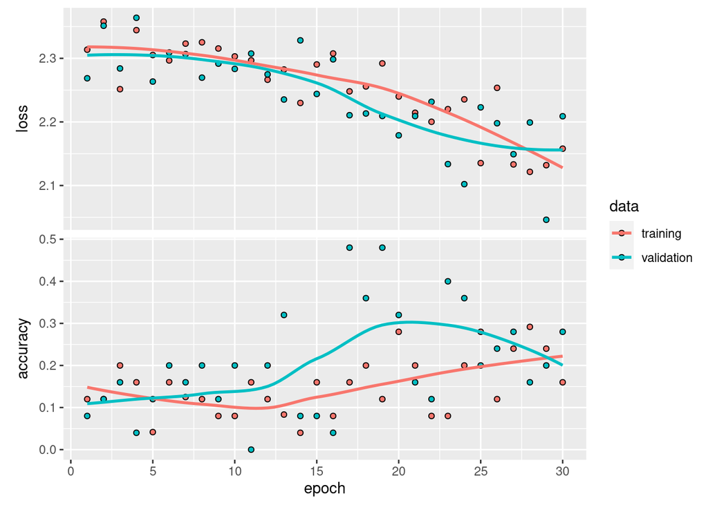

```r
plot(history_4)
```

## Evaluation the model

```r
test_generator_4 <- flow_images_from_directory(
  test_dir_10,
  test_datagen_10,
  target_size = c(150, 150),
  batch_size = 20,
  class_mode = "categorical"
)
results4 <- model %>% evaluate(test_generator_4, steps = 50)
loss4 <- round(results4[[1]], digits = 2)
accuracy4 <- round(results4[[2]], digits = 2)
```

The multi-class classification convolutional neural net demonstrated a loss of approximately 2.16 and an accuracy rate of approximately 0.22.

# Compare multi-class classification standard neural net vs convolutional neural net

Similar to the binary classification exercises, the multi-class classification convolutional neural net outperformed the standard neural net with a slightly higher accuracy and slightly lower loss function.